# One Model To Rule Them All

Alex Kale

9/24/2018

## Experiment 2

### Load Raw Data

These data were collected in a two-alternative forced choice experiement where participants judged stimuli at varying levels of evidence and were either correct or incorrect on each trial. In experiment 2, each participant was assigned to one of three possible uncertainty visualization conditions: regular HOPs, fast HOPs, or line ensembles.

```r
# e1df = read.csv("E1-AnonymousRawData-InferenceSample.csv")
e2df = read.csv("E2-AnonymousRawData.csv")
```

### Preprocessing

Reformat the raw data from the experiment as a list, changing types to integers as needed and taking the absolute value of ratio (i.e., stimulus intensity). This step will enable Stan to correctly process the data.

```r
# format data for model
e2data <- list(
  N = length(e2df$Ratio),
  S = length(unique(e2df$WorkerID)),
  correct = as.integer(e2df$Correct),
  intensity = abs(e2df$Ratio),
  hops = as.integer(e2df$Visualization=="h"),
  fast = as.integer(e2df$Visualization=="hf"),
  lines = as.integer(e2df$Visualization=="c"),
  subject = as.integer(as.factor(e2df$WorkerID))
)
```

### Model Specification

Our statistical model is a variation on *Bayesian hierarchical probit regression*.

We model the probability of a correct response from 0.5 (guessing) to 1 - lapse rate (the maximum estimated performance for each participant) as a function of stimulus intensity using a *scaled and shifted cumulative normal distribution*. This is called the *psychometric function*, and it will be used as the inverse link function in our regression model. Here are the parameters of the psychometric function:

- threshold: mean of the cumulative Gaussian in stimulus intensity units,
- spread: standard deviation (sd) of the cumulative Gaussian in stimulus intensity units,
- guess rate: the lower bound of the cumulative probability density which is .5 for a two alternative forced choice task with equally likely alternatives
- lapse rate: the rate of error for an individual due to lapses of attention which are independent of the stimulus

Below is the specification of the statistical model. Note the following features of the model:

- We are modelling correctness as a binomial distributed outcome with the probability of being correct as a transformed linear model of ratio and visualization condition.
- We use a *scaled and shifted probit* (the inverse of the psychometric function) as the link function for our linear model.
- The threshold, spread, and lapse rate parameters of the model are estimated for each subject while guess rate is assumed to be .5 based on the design of the experiment.
- We estimate the effect of each visualization condition via dummy coding and the effect of stimulus intensity (ratio).

The point of this exercise is that all parameters, both at the subject level (psychometric function parameters) and the group level (effects of visualization condition and stimulus intensity), are all estimated from raw data within one unified model.

```r
# model specification in Stan
stanCode <-
'data {
  int<lower=0> N; // number of obs
  int<lower=0> S; // number of subjects
  int<lower=0,upper=1> correct[N]; // correctness of judgments on each trial
  real<lower=0> intensity[N]; // stimulus intensity on each trial
  int<lower=0,upper=1> hops[N]; // dummy code for regular speed HOPs
  int<lower=0,upper=1> fast[N]; // dummy code for fast HOPs
  int<lower=0,upper=1> lines[N]; // dummy code for line ensembles
  int<lower=0> subject[N]; //subject index for each observation
}
parameters {
  real<lower=0,upper=15> threshold[S]; // estimate threshold, spread, and lapse parameters of the PF for each subject
  real<lower=0> spread[S];
  real<lower=0,upper=0.06> lapse[S];
  real a; // model coefficients
  real bi;
  real bh;
  real bf;
  real bl;
}
model {
  vector[N] p; // probability of being correct on each trial
  threshold ~ uniform(0,15); // threshold, spread, and lapse parameters of the PF
  spread ~ cauchy(0,1);
  lapse ~ uniform(0,.06);
  a ~ normal(0,10); //weak priors for model coefficients
  bi ~ normal(0,10);
  bh ~ normal(0,10);
  bf ~ normal(0,10);
  bl ~ normal(0,10);
  for (i in 1:N) {
    // linear model for effects on perceived stimulus intensity
    real lm;
    lm = a + bi*intensity[i] + bh*hops[i] + bf*fast[i] + bl*lines[i];
    // psychometric function as inverse link function
    p[i] = (0.5 - lapse[subject[i]])*Phi((lm - threshold[subject[i]])/spread[subject[i]]/sqrt(2.0)) + 0.5;
  }
  correct ~ binomial(1,p);
}'
```

Next we fit the model to our data using Stan.

```r
# run model
# (I used chains = 4, warmup = 500, & iter = 150 when creating the model in my environment.
# I cut this down to save time during Knit.)
e2m <- stan(
  model_code = stanCode,
  data = e2data,
  chains = 2,
  cores = 2,
  warmup = 300,
  iter = 1000
)
```

[output not shown]

### Check Model Perfomance

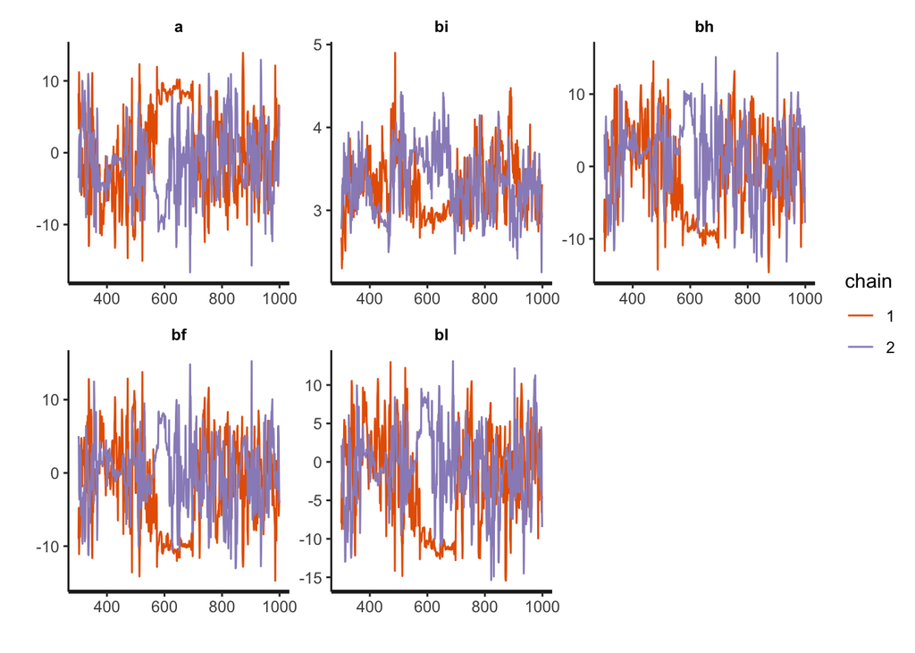

```r
traceplot(e2m,pars=c('a','bi','bh','bf','bl'))
```

Let’s also check whether our model had any problems identifying any of our parameters due to highly correltated parameter values. We check this using a pairs plot.

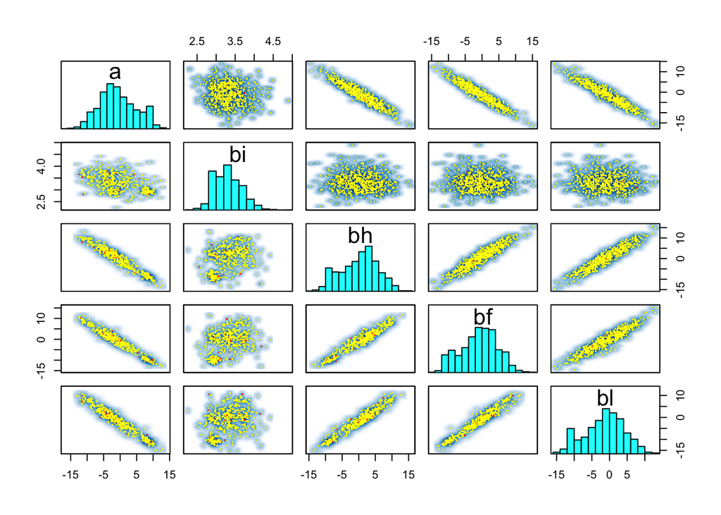

```r
pairs(e2m,pars=c('a','bi','bh','bf','bl'))
```

This does not look good. We may need to rethink the parameterization of this model in order to tease apart the model coefficients for our three visualization conditions. Currently, our model fit is probably not properly estimating these parameters due to non-identifiability.

### Results

Let’s take a look at our parameter estimates.

```
## ci_level: 0.8 (80% intervals)
```

```
## outer_level: 0.95 (95% intervals)
```

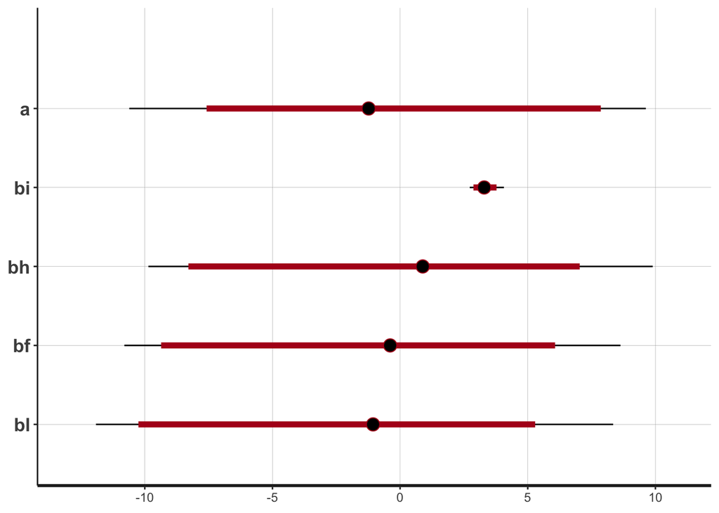

```r
plot(e2m,pars=c('a','bi','bh','bf','bl'))
```

We can see here that the point estimates follow the pattern we would expect based on the results of the frequentist model we report in the paper.

- bi: Increasing stimulus intensity increases the perceived level of evidence. This parameter is a good sanity check and it orients us to the meaning of the units for these model coefficients.
- bh: Regular speed HOPs increase the perceived level of evidence. This is consistent with reduced JNDs.
- bf: Fast HOPs seem to have a neutral impact on the perceived level of evidence.
- bl: Line ensembles seem to reduce the perceived level of evidence.

Note that the credibility intervals (CIs) on these estimates are very wide. We should expect that a Bayesian hierarchical model, designed to preserve uncertainty in PF fits at the level of estimating population parameters, will be more conservative and have wider CIs However, this might also reflect problems with identifiability in our model.